# 15.Statistics Introduction

Let's first start with some definitions

Definition:

1. **Statistics** - The study of the collection, organization, analysis, and interpretation of data.

Definition:

1. **Population** - The entire collection of objects, measurements, observations, etc.

Definition:

1. **Sample** - A representative subset of a population.

Definition:

1. **Random Variable** - A variable being measured.
- Discrete

outcomes of a coin toss or six-sided die

- Continuous

the lifetime of a light bulb

Definition:

1. **Distribution function** - A graphical or mathematical representation of a random variable.

most common distribution function is a bell curve

Definition:

1. **Probability** - The chance of occurrence of an event.

numeric value ranging from 0 to 1

$$ P \left( A\ or\ B \right) = P \left( A \right) + P \left( B \right) $$

the probability of event $ A $ or $ B $ occurring is the probability of event $ A $ happening plus the probability of event $ B $ occurring

rolling a 3 or 4 on a six-sided die

$$ P\left(AB\right) = P\left(A\right)\cdot P\left(B\right) $$

rolling a three on a six sided die and flipping heads on a coin

## Measure of Central Tendency

The mean of a sample

$$ \bar x = \frac{x_1 + x_2 + \cdots + x_n}{n} = \sum_{i = 1}^{n} \frac{x_i}{n} $$

The mean of a population

$$ \mu = \sum_{i=1}^{N} \frac{x_i}{N} $$

Definition:

1. **Median** - The central value of data set.

Definition:

1. **Mode** - The value of the variable that corresponds to the peak value of the probability of occurrence.

## Measure of Dispersion

Deviation $ d $ of a particular data point $ i $

$$ d_i = x_i - \bar x$$

The standard deviation of a sample

$$ S = \sqrt{\sum_{i=1}^n \frac{\left(x_i - \bar x\right)^2}{n-1}} $$

The standard deviation of a finite population

$$ \sigma = \sqrt{\sum_{i = 1}^N \frac{\left( x_i - \mu \right)^2}{N}} $$

## Histograms

Definition:

1. **Histogram** - A graphical method to represent the occurrence of data.

creating a histogram

1. Determine the number of data points in the data set $ n $.
2. Determine the range $ R $ for the entire data set. The range is the largest value in the data set minus the smallest value.
3. Divide the range $ R $ by the number of bins $ B $ that you want in your histogram. Table 1 below provides an approximate guideline for dividing your data set into a reasonable number of bins.

Table 1: Histogram Bin Number Selection Guide

| Number of data points, $ n $ | Number of bins, $ B $ |
| --- | --- |
| $\lt 50$ | $5-7$ |
| $50-100$ | $6-10$ |
| $100-250$ | $7-12$ |
| $\gt 250$ | $10-20$ |

4. Determine the bin width $ W $. A convenient formula is $ W = R / B $. The bin width is the width of each of the bars on your histogram. You may want to round the value of $ W $ off to make your histogram more clear.
5. Choose the starting point (a rounded-off value near the minimum value in the data set) and determine the numerical value where each of the divisions will occur based on the width $ W $ of each bin.
6. Count the number of data points in each division (whose width is $ W $).
7. Create the histogram. The histogram creation may be done in Excel as a bar chart.

## Example: Exam Grades

**Given and Required:**

For the exam grades in the file exam_grades.csv, create a histogram with an appropriate bin size.

**Solution:**

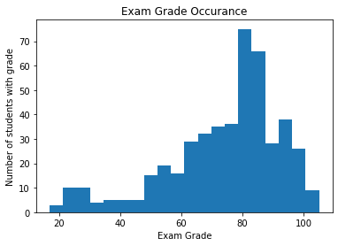

```python
fig, ax = plt.subplots(1, 1)

ax.hist(data, bins = B)

ax.set_title('Exam Grade Occurance')
ax.set_xlabel('Exam Grade')
ax.set_ylabel('Number of students with grade')

plt.show()
```

[output not shown]